# Introduction to Deep Reinforcement Learning

Reinforcement learning (RL) is learning what to do, given **a situation** and **a set of possible actions** to choose from, in order to **maximize a reward**. The learner, which we will call **agent**, is not told what to do, he must discover this by himself through interacting with the environment. The goal is to choose its actions in such a way that the **cumulative reward is maximized**. So, choosing the best reward now, might not be the best decision, in the long run. That is **greedy approaches might not be optimal**.

[figure not shown]

We have an **agent** and an **environment**. The environment gives the agent a state. The agent chooses an action and receives a reward from the environment along with the new state. This learning process continues until the goal is achieved or some other condition is met.

[figure not shown]

### Markov Processes

A Markov process is a random process indexed by time, and with the property that **the future is independent of the past**, given the present. For example, running a maze is a markov process. But **if each position can only be passed for once**, it's **not a markov process**.

#### Is Go a markov process?

[figure not shown]

## Deep Q-learning

### Q-learning

The goal of Q-Learning is to learn a policy, which tells an agent **which action to take under which circumstances**. It **does not require a model of the environment** and can handle problems with stochastic transitions and rewards, without requiring adaptations.

[figure not shown]

For Q-learning, we want to calculate the **state-action** value.

[figure not shown]

And the update process should be as following:

[figure not shown]

where **γ** is the **discount factor**.

To do the update process, we need two additional steps, **exploration** and **replay**.

#### Exploration

We should do exploration to collect **(state, action, reward, new_state)** pair for **updating** our state-action value. Insted of greedy exploration, we do **epsilon-greedy** to force exploring newer state. That is, the explorer will **have a probability to do random action** instead of choosing the one with largest state-action value.

[figure not shown]

#### Replay

We use a buffer to **save our collected experience**. After each exploration, we will **sample some experiences from the buffer** and update state-action value based on them. In general, the buffer will have a limited size, and **older experience will be discarded**. This mechanism can **make sampled experience newer and newer** during exploration.

### "Deep" Q-learning

For traditional Q-learning, we use **a table** to save the state-action value. While, for **high dimension or continuous states** like image, it's impossible to preserve such many and complex pairs. Instead of table, we use a neural network to represent the state-action value, where the **input is a state** and the **output is the state-action value for each action**.

[figure not shown]

### Training Process

Explorer will first apply epsilon-greedy to explore the environment and save collected experiences in replay buffer. Then, we sample some pairs from replay buffer and update our state-action network. Repeat above steps until our state-action network converge. Pleas noted that **with more exploration and update**, explorer should **do less random action** which means we have more confidence for the prediction from state-action network.

[figure not shown]

## Game1: CartPole

A pole is attached by an un-actuated joint to a cart, which moves along a frictionless track. The system is controlled by applying a **force of +1 or -1 to the cart**. The pendulum starts upright, and the goal is to **prevent it from falling over**. A reward of +1 is provided for every timestep that the pole remains upright. The episode ends when the pole is more than 15 degrees from vertical, or the cart moves more than 2.4 units from the center.

[figure not shown]

### OpenAI Gym

[Gym](https://gym.openai.com/) is a toolkit for developing and comparing reinforcement learning algorithms.

```python
!apt-get install -y python-numpy python-dev cmake zlib1g-dev libjpeg-dev xvfb libav-tools xorg-dev python-opengl libboost-all-dev libsdl2-dev swig
!pip3 install gym[all] opencv-python matplotlib
```

```python
import gym

env = gym.make('CartPole-v0')
env.reset()
# env.render()

obs_n = list(env.observation_space.shape)
act_n = int(env.action_space.n)
print('OBS_N:', obs_n)
print('ACT_N:', act_n)
```

```
WARN: gym.spaces.Box autodetected dtype as <class 'numpy.float32'>. Please provide explicit dtype.
OBS_N: [4]
ACT_N: 2
```

### ReplayBuffer

- We use a [deque](https://docs.python.org/3/library/collections.html) with limited size as the container
- There are 2 methods we should implement, **add** and **sample**

#### - add

save the collected experience, including **prv_obs, action, reward, done, and cur_obs**

#### - sample

**random select** some pairs in buffer

```python
from collections import deque
import numpy as np


class ReplayBuffer:
  def __init__(self, replay_size=20000):
    super(ReplayBuffer, self).__init__()

    self.buffer = deque(maxlen=replay_size)

  def add(self, prv_obs, action, reward, done, cur_obs):

    ############################################################
    # PLEASE IMPLEMENT HERE                                    #
    ############################################################

  def sample(self, batch_size=32):

    ############################################################
    # PLEASE IMPLEMENT HERE                                    #
    ############################################################

    prv_obs = np.asarray([self.buffer[i][0] for i in idxs])
    cur_obs = np.asarray([self.buffer[i][4] for i in idxs])
    action = [self.buffer[i][1] for i in idxs]
    reward = [self.buffer[i][2] for i in idxs]
    done = [self.buffer[i][3] for i in idxs]

    return prv_obs, action, reward, done, cur_obs

replay = ReplayBuffer()

env = gym.make('CartPole-v0')
prv_obs = env.reset()
for t in range(100):
  action = env.action_space.sample()
  cur_obs, reward, done, info = env.step(action)

  ############################################################
  # PLEASE IMPLEMENT HERE                                    #
  ############################################################

  prv_obs = cur_obs

  if done==True:
    print('Finish at %d'%(t))
    break

for i in range(3):
  print(replay.buffer[i][0], replay.buffer[i][4])

prv_obs, action, reward, done, cur_obs = replay.sample(batch_size=8)
print(prv_obs.shape)
```

```
WARN: gym.spaces.Box autodetected dtype as <class 'numpy.float32'>. Please provide explicit dtype.
Finish at 15
[-0.03779195 -0.00472232  0.04836959 -0.02386443] [-0.03788639 -0.20050337  0.0478923   0.28367878]
[-0.03788639 -0.20050337  0.0478923   0.28367878] [-0.04189646 -0.00609605  0.05356588  0.00647713]
[-0.04189646 -0.00609605  0.05356588  0.00647713] [-0.04201838  0.1882184   0.05369542 -0.26883565]
(8, 4)
```

### Deep Q Network

- We use **2-layer MLP** as hidden layer of our DQN
- There are 3 methods we should implement, **predict, get_action, and train**

#### - predict

output the **state-action value** of given state

#### - get_action

apply **epsilon-greedy exploration** for given state

#### - train

given experience pairs, **update our DQN**

```python
import tensorflow as tf

class DQN:
  def __init__(self, obs_n, act_n, learning_rate=0.001):
    super(DQN, self).__init__()

    self.input = tf.placeholder(tf.float32, shape=[None]+obs_n)
    self.groundtruth = tf.placeholder(tf.float32, shape=[None, act_n])

    ############################################################
    # PLEASE IMPLEMENT HERE                                    #
    ############################################################

    self.loss = tf.losses.mean_squared_error(labels=self.groundtruth, predictions=self.out)
    self.optimizer = tf.train.AdamOptimizer(learning_rate=learning_rate).minimize(self.loss)

    self.sess = tf.Session()
    self.saver = tf.train.Saver()
    self.sess.run(tf.global_variables_initializer())

  def predict(self, obs):

    ############################################################
    # PLEASE IMPLEMENT HERE                                    #
    ############################################################

    return out

  def get_action(self, obs, explore=0):
    obs = np.reshape(obs, (1, 4))

    if np.random.rand()>=explore:

      ############################################################
      # PLEASE IMPLEMENT HERE                                    #
      ############################################################

    else:

      ############################################################
      # PLEASE IMPLEMENT HERE                                    #
      ############################################################

    return action

  def train(self, prv_obs, action, reward, done, cur_obs, gamma=0.99):
    groundtruth = self.predict(prv_obs)

    ############################################################
    # PLEASE IMPLEMENT HERE                                    #
    ############################################################

    for i in range(prv_obs.shape[0]):
      if done[i]==True:

        ############################################################
        # PLEASE IMPLEMENT HERE                                    #
        ############################################################

      else:

        ############################################################
        # PLEASE IMPLEMENT HERE                                    #
        ############################################################

    _, loss = self.sess.run([self.optimizer, self.loss], feed_dict={self.input: prv_obs, self.groundtruth: groundtruth})

    return loss

dqn = DQN(obs_n=obs_n, act_n=act_n)
prv_obs, action, reward, done, cur_obs = replay.sample(batch_size=32)
loss = dqn.train(prv_obs, action, reward, done, cur_obs)
print('Loss: %.4f'%(loss))
```

```
Loss: 0.5535
```

### Preparation for Training

- the hyperparameters
- **GAMMA**: the reward discount factor
- **EXPLORE, MIN_EXPLORE, DECAY**: the probability of epsilon-greedy and the decay rate
- **EPISODES**: the times we play game for training

```python
ENV_NAME = 'CartPole-v0'

GAMMA = 0.99
EXPLORE = 0.9
MIN_EXPLORE = 0.1
DECAY = 0.995

EPISODES = 150
```

```python
env = gym.make(ENV_NAME)
replay = ReplayBuffer()
dqn = DQN(obs_n=obs_n, act_n=act_n)
```

```
WARN: gym.spaces.Box autodetected dtype as <class 'numpy.float32'>. Please provide explicit dtype.
```

#### - train

**sample** experiences from reaply buffer and **train** our DQN

#### - valid

**validate** the existing DQN via playing **n times** (Please noted that during validation, we won't apply epsilon-greedy anymore)

```python
def train(dqn, replay):

  ############################################################
  # PLEASE IMPLEMENT HERE                                    #
  ############################################################

  return loss

def valid(env, dqn, n=5):
  total_reward = 0

  for _ in range(n):
    prv_obs = env.reset()

    ############################################################
    # PLEASE IMPLEMENT HERE                                    #
    ############################################################

  avg_reward = total_reward/n

  return avg_reward
```

```python
init_reward = valid(env, dqn)
print('Init reward: %d'%(init_reward))
```

```
Init reward: 61
```

#### Training

Don't forget to **save the best model** so far.

```python
explore = EXPLORE
best = -99

rec_reward = []
rec_valid = []

for e in range(EPISODES):
  ep_loss = 0
  ep_reward = 0
  t = 0
  prv_obs = env.reset()

  while True:
    t += 1

    ############################################################
    # PLEASE IMPLEMENT HERE                                    #
    ############################################################

    ep_reward += reward
    ep_loss += train(dqn=dqn, replay=replay)

    if done==True:
      ep_loss /= t
      print('')
      print('Episode %d: loss=%.4f, reward=%d, step=%d' % (e+1, ep_loss, ep_reward, t))

      val = valid(env, dqn=dqn)
      print('Valid: %.2f'%(val))

      rec_reward.append(ep_reward)
      rec_valid.append(val)

      ############################################################
      # PLEASE IMPLEMENT HERE                                    #
      ############################################################

      break

    explore = max(MIN_EXPLORE, explore*DECAY)
```

#### Evaluation

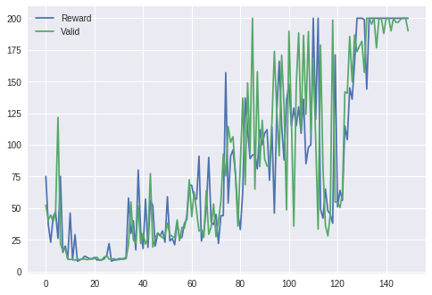

```python
import matplotlib.pyplot as plt

plt.plot(rec_reward, label='Reward')
plt.plot(rec_valid, label='Valid')
plt.legend()

plt.show()
```

```python
dqn.saver.restore(dqn.sess, './cart_pole.ckpt')
val = valid(env=env, dqn=dqn)
print('Final reward: %.2f'%(val))
```

```
INFO:tensorflow:Restoring parameters from ./cart_pole.ckpt
Final reward: 199.20
```

## Game2: Pong

Pong is a table tennis game from [Atari 2600](https://gym.openai.com/envs/#atari). Player controls an in-game paddle by **moving it vertically across the left or right side** of the screen. And the goal is for each player to reach **21 points** before the opponent; points are earned when one fails to return the ball to the other.

[figure not shown]

```python
import gym

env = gym.make('PongDeterministic-v4')

obs_n = list(env.observation_space.shape)
act_n = int(env.action_space.n)
print('OBS_N:', obs_n)
print('ACT_N:', act_n)
```

```
OBS_N: [210, 160, 3]
ACT_N: 6
```

[figure not shown]

```python
import matplotlib.pyplot as plt

obs = env.reset()
plt.axis('off')
plt.imshow(obs)
plt.show()
```

```python
env = gym.make('PongDeterministic-v4')
env.reset()

total_reward = 0
for t in range(1500):
  action = env.action_space.sample()
  obs, reward, done, info = env.step(action)
  total_reward += reward

  if done==True:
    print('Finish at %d'%(t))
    print('Total_reward: %d'%(total_reward))

    break
```

```
Finish at 910
Total_reward: -21
```

### Observation Preprocessing

Since the input state is high dimension, we want to **resize** it into smaller frame and **downgrade to grayscale**.

#### - transforms

downgrade, resize, and normalize the input state

[figure not shown]

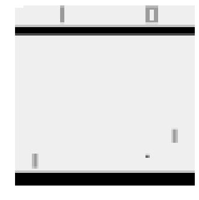

[figure not shown]

[figure not shown]

[figure not shown]

[figure not shown]

```python
import cv2

NEW_OBS_N = 84

def transforms(obs):
    obs = obs.astype('float32')

    ############################################################
    # PLEASE IMPLEMENT HERE                                    #
    ############################################################

    return obs

env = gym.make('PongDeterministic-v4')
env.reset()

for _ in range(100):
  env.step(env.action_space.sample())

for _ in range(3):
  obs = env.render(mode='rgb_array')
  plt.figure()
  plt.axis('off')
  plt.imshow(obs)
  plt.show()

  obs = transforms(obs)
  plt.figure()
  plt.axis('off')
  plt.imshow(obs)
  plt.show()

  action = env.action_space.sample()
  env.step(action)
```

### Frame Stacked

Given a state, it's not clear that how will the ball moving. We **stack serveral previous frames along with current frame** as a new state and make the information more sufficeient for our DQN to determine.

[figure not shown]

### CNN-based Deep Q Network

Since the input state is more complicated and similar to image, we use a **CNN-based network** this time. Here we design **2 convolution blocks**, followed by **2-layer MLP** as our DQN architecture.

[figure not shown]

### Start Your Training!

Now, you can train the Pong DQN agent by your self. Following is the recommended hyperparameters and the reference code can be found [here](https://tsujuifu.github.io/projs/2018_vlss/ref_pong). In my case, after training 400 episodes (~8hr on single GTX 1080 Ti), the reward achieve 21 which means our DQN agent can beat it 21-0.

```python
ENV_NAME = 'PongDeterministic-v4'

STACK = 4
LR = 0.0005

REPLAY_SIZE = 20000
BATCH_SIZE = 64

GAMMA = 0.99
EXPLORE = 0.9
MIN_EXPLORE = 0.1
DECAY = 0.999995

EPISODES = 400
```

## Advanced Skills

- [Deep Reinforcement Learning with Double Q-learning](https://arxiv.org/abs/1509.06461)
- [Reinforcement Learning with Unsupervised Auxiliary Tasks](https://arxiv.org/abs/1611.05397)
- [Prioritized Experience Replay](https://arxiv.org/abs/1511.05952)
- [Curiosity-driven Exploration by Self-supervised Prediction](https://arxiv.org/abs/1705.05363)
- [Diversity-Driven Exploration Strategy for Deep Reinforcement Learning](https://arxiv.org/abs/1802.04564)

## Reference

- [Human-level control through deep reinforcement learning](https://www.nature.com/articles/nature14236)
- [Playing Atari with Deep Reinforcement Learning](https://arxiv.org/abs/1312.5602)
- [DQN 從入門到放棄](https://zhuanlan.zhihu.com/p/21262246)
- [DQN FlappyBird](https://github.com/yenchenlin/DeepLearningFlappyBird)